# Chapter 3

# Multiple Linear Regression

### 3.1

**Verify that the coefficient of $X_1$ can be obtained from a series of simple regression equations**

```r
# Supervisor data set
df <- read_delim("data/P060.txt", "\t",
                 escape_double = FALSE, trim_ws = TRUE)
df
```

| Y | X1 | X2 | X3 | X4 | X5 | X6 |
| --- | --- | --- | --- | --- | --- | --- |
| 43 | 51 | 30 | 39 | 61 | 92 | 45 |
| 63 | 64 | 51 | 54 | 63 | 73 | 47 |
| 71 | 70 | 68 | 69 | 76 | 86 | 48 |
| 61 | 63 | 45 | 47 | 54 | 84 | 35 |
| 81 | 78 | 56 | 66 | 71 | 83 | 47 |
| 43 | 55 | 49 | 44 | 54 | 49 | 34 |
| 58 | 67 | 42 | 56 | 66 | 68 | 35 |
| 71 | 75 | 50 | 55 | 70 | 66 | 41 |
| 72 | 82 | 72 | 67 | 71 | 83 | 31 |
| 67 | 61 | 45 | 47 | 62 | 80 | 41 |

[output cut: 20 more lines]

First, model both together

```r
mod0 <- lm(Y ~ X1 + X2, df)
summary(mod0)
```

```
Call:
lm(formula = Y ~ X1 + X2, data = df)

Residuals:
     Min       1Q   Median       3Q      Max
-12.7887  -5.6893  -0.0284   6.2745   9.9726

Coefficients:
            Estimate Std. Error t value Pr(>|t|)
(Intercept) 15.32762    7.16023   2.141   0.0415 *
X1           0.78034    0.11939   6.536 5.22e-07 ***
X2          -0.05016    0.12992  -0.386   0.7025
---
Signif. codes:  0 ‘***’ 0.001 ‘**’ 0.01 ‘*’ 0.05 ‘.’ 0.1 ‘ ’ 1

Residual standard error: 7.102 on 27 degrees of freedom
Multiple R-squared:  0.6831,    Adjusted R-squared:  0.6596
F-statistic:  29.1 on 2 and 27 DF,  p-value: 1.833e-07
```

Now separately:

1. Fit the simple regression model that relates $Y$ to $X_2$. Let the residuals from this regression be denoted by eY_X2.

```r
mod1 <- lm(Y ~ X2, data = df)
summary(mod1)
```

```
Call:
lm(formula = Y ~ X2, data = df)

Residuals:
     Min       1Q   Median       3Q      Max
-20.9357  -5.7397  -0.1691   5.6026  23.3582

Coefficients:
            Estimate Std. Error t value Pr(>|t|)
(Intercept)  42.1087     9.2661   4.544 9.63e-05 ***
X2            0.4239     0.1701   2.492   0.0189 *
---
Signif. codes:  0 ‘***’ 0.001 ‘**’ 0.01 ‘*’ 0.05 ‘.’ 0.1 ‘ ’ 1

Residual standard error: 11.21 on 28 degrees of freedom
Multiple R-squared:  0.1816,    Adjusted R-squared:  0.1523
F-statistic: 6.212 on 1 and 28 DF,  p-value: 0.01888
```

```r
df$eY_X2 <- mod1$residuals
df[c("Y", "X2", "eY_X2")]
```

| Y | X2 | eY_X2 |
| --- | --- | --- |
| 43 | 30 | -11.82647953 |
| 63 | 51 | -0.72895488 |
| 71 | 68 | 0.06427935 |
| 61 | 45 | -0.18539050 |
| 81 | 56 | 15.15140813 |
| 43 | 49 | -19.88110009 |
| 58 | 42 | -1.91360830 |
| 71 | 50 | 7.69497251 |
| 72 | 72 | -0.63143024 |
| 67 | 45 | 5.81460950 |

[output cut: 20 more lines]

The fitted regression equation is

$$Y = 42.1087 + 0.4239X_2$$

2. Fit the simple regression model that relates $X_1$ (temporarily considered response variable) to $X_2$. Let the residuals from this regression be denoted by eX1_X2.

```r
mod2 <- lm(X1 ~ X2, df)
summary(mod2)
```

```
Call:
lm(formula = X1 ~ X2, data = df)

Residuals:
     Min       1Q   Median       3Q      Max
-22.8361  -5.7851  -0.9813   7.4500  25.3036

Coefficients:
            Estimate Std. Error t value Pr(>|t|)
(Intercept)  34.3196     9.2950   3.692 0.000953 ***
X2            0.6075     0.1706   3.561 0.001346 **
---
Signif. codes:  0 ‘***’ 0.001 ‘**’ 0.01 ‘*’ 0.05 ‘.’ 0.1 ‘ ’ 1

Residual standard error: 11.24 on 28 degrees of freedom
Multiple R-squared:  0.3117,    Adjusted R-squared:  0.2871
F-statistic: 12.68 on 1 and 28 DF,  p-value: 0.001346
```

```r
df$eX1_X2 <- mod2$residuals
df[c("Y", "X2", "eY_X2", "eX1_X2")]
```

| Y | X2 | eY_X2 | eX1_X2 |
| --- | --- | --- | --- |
| 43 | 30 | -11.82647953 | -1.54565277 |
| 63 | 51 | -0.72895488 | -1.30392187 |
| 71 | 68 | 0.06427935 | -5.63204447 |
| 61 | 45 | -0.18539050 | 1.34129787 |
| 81 | 56 | 15.15140813 | 9.65839501 |
| 43 | 49 | -19.88110009 | -9.08884862 |
| 58 | 42 | -1.91360830 | 7.16390774 |
| 71 | 50 | 7.69497251 | 10.30361475 |
| 72 | 72 | -0.63143024 | 3.93780904 |
| 67 | 45 | 5.81460950 | -0.65870213 |

[output cut: 20 more lines]

```r
mod3 <- lm(eY_X2 ~ 0 + eX1_X2, df)
summary(mod3)
```

```
Call:
lm(formula = eY_X2 ~ 0 + eX1_X2, data = df)

Residuals:
     Min       1Q   Median       3Q      Max
-12.7887  -5.6893  -0.0284   6.2745   9.9726

Coefficients:
       Estimate Std. Error t value Pr(>|t|)
eX1_X2   0.7803     0.1152   6.774 1.95e-07 ***
---
Signif. codes:  0 ‘***’ 0.001 ‘**’ 0.01 ‘*’ 0.05 ‘.’ 0.1 ‘ ’ 1

Residual standard error: 6.853 on 29 degrees of freedom
Multiple R-squared:  0.6127,    Adjusted R-squared:  0.5994
F-statistic: 45.89 on 1 and 29 DF,  p-value: 1.953e-07
```

The fitted regression equation:

$$\hat{e}_{Y.X_2} = 0 + 0.7803e_{X_1.X_2}$$
### 3.3

Examination data

```r
df_exam <- read_delim("data/P083.txt", "\t",
                      escape_double = FALSE, trim_ws = TRUE)
df_exam
```

| F | P1 | P2 |
| --- | --- | --- |
| 68 | 78 | 73 |
| 75 | 74 | 76 |
| 85 | 82 | 79 |
| 94 | 90 | 96 |
| 86 | 87 | 90 |
| 90 | 90 | 92 |
| 86 | 83 | 95 |
| 68 | 72 | 69 |
| 55 | 68 | 67 |
| 69 | 69 | 70 |

[output cut: 12 more lines]

Model 1: $F = \beta_0 + \beta_1P_1 + \varepsilon$

```r
mod_exam1 <- lm(F ~ P1, df_exam)
summary(mod_exam1)
```

```
Call:
lm(formula = F ~ P1, data = df_exam)

Residuals:
   Min     1Q Median     3Q    Max
-8.844 -2.020 -0.587  4.043  7.938

Coefficients:
            Estimate Std. Error t value Pr(>|t|)
(Intercept) -22.3424    11.5640  -1.932   0.0676 .
P1            1.2605     0.1399   9.008 1.78e-08 ***
---
Signif. codes:  0 ‘***’ 0.001 ‘**’ 0.01 ‘*’ 0.05 ‘.’ 0.1 ‘ ’ 1

Residual standard error: 5.081 on 20 degrees of freedom
Multiple R-squared:  0.8023,    Adjusted R-squared:  0.7924
F-statistic: 81.14 on 1 and 20 DF,  p-value: 1.779e-08
```

Model 2: $F = \beta_0 + \beta_2P_2 + \varepsilon$

```r
mod_exam2 <- lm(F ~ P2, df_exam)
summary(mod_exam2)
```

```
Call:
lm(formula = F ~ P2, data = df_exam)

Residuals:
     Min       1Q   Median       3Q      Max
-10.4323  -1.5027   0.5421   2.2580   7.5165

Coefficients:
            Estimate Std. Error t value Pr(>|t|)
(Intercept) -1.85355    7.56181  -0.245    0.809
P2           1.00427    0.09059  11.086 5.44e-10 ***
---
Signif. codes:  0 ‘***’ 0.001 ‘**’ 0.01 ‘*’ 0.05 ‘.’ 0.1 ‘ ’ 1

Residual standard error: 4.275 on 20 degrees of freedom
Multiple R-squared:   0.86, Adjusted R-squared:  0.853
F-statistic: 122.9 on 1 and 20 DF,  p-value: 5.442e-10
```

Model 3: $F = \beta_0 + \beta_1P_1 + \beta_2P_2 + \varepsilon$

```r
mod_exam3 <- lm(F ~ P1 + P2, df_exam)
summary(mod_exam3)
```

```
Call:
lm(formula = F ~ P1 + P2, data = df_exam)

Residuals:
    Min      1Q  Median      3Q     Max
-8.7328 -2.1703  0.3938  2.6443  6.3660

Coefficients:
            Estimate Std. Error t value Pr(>|t|)
(Intercept) -14.5005     9.2356  -1.570  0.13290
P1            0.4883     0.2330   2.096  0.04971 *
P2            0.6720     0.1793   3.748  0.00136 **
---
Signif. codes:  0 ‘***’ 0.001 ‘**’ 0.01 ‘*’ 0.05 ‘.’ 0.1 ‘ ’ 1

Residual standard error: 3.953 on 19 degrees of freedom
Multiple R-squared:  0.8863,    Adjusted R-squared:  0.8744
F-statistic: 74.07 on 2 and 19 DF,  p-value: 1.069e-09
```

```r
new_exam_dat = data.frame(P1 = 78, P2 = 85)
predict(mod_exam3, new_exam_dat, interval = "prediction")
```

```
       fit      lwr     upr
1 80.71282 71.79724 89.6284
```

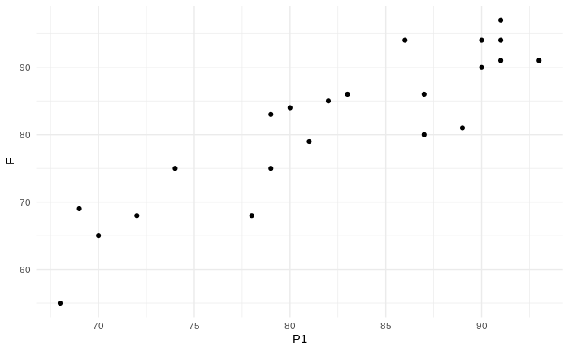

```r
df_exam %>%
  ggplot(aes(P1, F)) +
  geom_point()
```

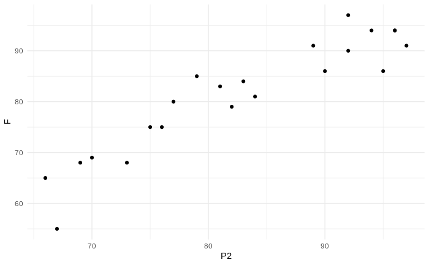

```r
df_exam %>%
  ggplot(aes(P2, F)) +
  geom_point()
```

### 3.15

**Cigarette data**

```r
df_cig <- read_delim("data/P088.txt", "\t",
                     escape_double = FALSE, trim_ws = TRUE)
df_cig
```

| State | Age | HS | Income | Black | Female | Price | Sales |
| --- | --- | --- | --- | --- | --- | --- | --- |
| AL | 27.0 | 41.3 | 2948 | 26.2 | 51.7 | 42.7 | 89.8 |
| AK | 22.9 | 66.7 | 4644 | 3.0 | 45.7 | 41.8 | 121.3 |
| AZ | 26.3 | 58.1 | 3665 | 3.0 | 50.8 | 38.5 | 115.2 |
| AR | 29.1 | 39.9 | 2878 | 18.3 | 51.5 | 38.8 | 100.3 |
| CA | 28.1 | 62.6 | 4493 | 7.0 | 50.8 | 39.7 | 123.0 |
| CO | 26.2 | 63.9 | 3855 | 3.0 | 50.7 | 31.1 | 124.8 |
| CT | 29.1 | 56.0 | 4917 | 6.0 | 51.5 | 45.5 | 120.0 |
| DE | 26.8 | 54.6 | 4524 | 14.3 | 51.3 | 41.3 | 155.0 |
| DC | 28.4 | 55.2 | 5079 | 71.1 | 53.5 | 32.6 | 200.4 |
| FL | 32.3 | 52.6 | 3738 | 15.3 | 51.8 | 43.8 | 123.6 |

[output cut: 41 more lines]

“State” is not a variable, it’s a label.

```r
mod_cig1 <- lm(Sales ~ Age + HS + Income + Black + Female + Price, df_cig)
summary(mod_cig1)
```

```
Call:
lm(formula = Sales ~ Age + HS + Income + Black + Female + Price,
    data = df_cig)

Residuals:
    Min      1Q  Median      3Q     Max
-48.398 -12.388  -5.367   6.270 133.213

Coefficients:
             Estimate Std. Error t value Pr(>|t|)
(Intercept) 103.34485  245.60719   0.421  0.67597
Age           4.52045    3.21977   1.404  0.16735
HS           -0.06159    0.81468  -0.076  0.94008
Income        0.01895    0.01022   1.855  0.07036 .
Black         0.35754    0.48722   0.734  0.46695
Female       -1.05286    5.56101  -0.189  0.85071
Price        -3.25492    1.03141  -3.156  0.00289 **
---
Signif. codes:  0 ‘***’ 0.001 ‘**’ 0.01 ‘*’ 0.05 ‘.’ 0.1 ‘ ’ 1

Residual standard error: 28.17 on 44 degrees of freedom
Multiple R-squared:  0.3208,    Adjusted R-squared:  0.2282
F-statistic: 3.464 on 6 and 44 DF,  p-value: 0.006857
```

1. Test hypothesis that Female is not needed.

This variable shows up as not significant in the full model (p = 0.85). Model without it:

```r
mod_cig2 <- lm(Sales ~ Age + HS + Income + Black + Price, df_cig)
summary(mod_cig2)
```

```
Call:
lm(formula = Sales ~ Age + HS + Income + Black + Price, data = df_cig)

Residuals:
    Min      1Q  Median      3Q     Max
-47.089 -11.767  -5.525   5.650 132.873

Coefficients:
             Estimate Std. Error t value Pr(>|t|)
(Intercept) 59.463336  80.387585   0.740  0.46332
Age          4.117758   2.391184   1.722  0.09193 .
HS          -0.066817   0.805446  -0.083  0.93425
Income       0.019458   0.009746   1.997  0.05194 .
Black        0.311472   0.417577   0.746  0.45961
Price       -3.252022   1.020186  -3.188  0.00261 **
---
Signif. codes:  0 ‘***’ 0.001 ‘**’ 0.01 ‘*’ 0.05 ‘.’ 0.1 ‘ ’ 1

Residual standard error: 27.87 on 45 degrees of freedom
Multiple R-squared:  0.3203,    Adjusted R-squared:  0.2448
F-statistic: 4.241 on 5 and 45 DF,  p-value: 0.003039
```

Adjusted R-squared improves from 0.2282 to 0.2448, p-value of F-statistic is also (more) significant.

2. Test the hypothesis that Female and HS are not needed (HS has the next worst p-value).

```r
mod_cig3 <- lm(Sales ~ Age + Income + Black + Price, df_cig)
summary(mod_cig3)
```

```
Call:
lm(formula = Sales ~ Age + Income + Black + Price, data = df_cig)

Residuals:
    Min      1Q  Median      3Q     Max
-46.784 -11.810  -5.380   5.758 132.789

Coefficients:
             Estimate Std. Error t value Pr(>|t|)
(Intercept) 55.329580  62.395293   0.887   0.3798
Age          4.191538   2.195535   1.909   0.0625 .
Income       0.018892   0.006882   2.745   0.0086 **
Black        0.334162   0.312098   1.071   0.2899
Price       -3.239941   0.998778  -3.244   0.0022 **
---
Signif. codes:  0 ‘***’ 0.001 ‘**’ 0.01 ‘*’ 0.05 ‘.’ 0.1 ‘ ’ 1

Residual standard error: 27.57 on 46 degrees of freedom
Multiple R-squared:  0.3202,    Adjusted R-squared:  0.2611
F-statistic: 5.416 on 4 and 46 DF,  p-value: 0.001168
```

R-squared stays around the same, Adjusted R-squared improves, F-statistic improves in significance.

3. Calculate 95% confint for coefficient of Income

```r
confint(mod_cig3)
```

```
                    2.5 %       97.5 %
(Intercept) -70.265630707 180.92479099
Age          -0.227844448   8.61092094
Income        0.005038974   0.03274515
Black        -0.294058799   0.96238365
Price        -5.250375936  -1.22950536
```

4. What percent of the variation in Sales can be accounted for when Income is removed from the above equation?

```r
mod_cig4 <- lm(Sales ~ Age + Black + Price, df_cig)
summary(mod_cig4)
```

```
Call:
lm(formula = Sales ~ Age + Black + Price, data = df_cig)

Residuals:
    Min      1Q  Median      3Q     Max
-32.607 -15.896  -5.519   5.159 133.851

Coefficients:
            Estimate Std. Error t value Pr(>|t|)
(Intercept)  72.8741    66.2420   1.100   0.2769
Age           5.4900     2.2882   2.399   0.0204 *
Black         0.3794     0.3326   1.141   0.2598
Price        -2.7818     1.0510  -2.647   0.0110 *
---
Signif. codes:  0 ‘***’ 0.001 ‘**’ 0.01 ‘*’ 0.05 ‘.’ 0.1 ‘ ’ 1

Residual standard error: 29.42 on 47 degrees of freedom
Multiple R-squared:  0.2088,    Adjusted R-squared:  0.1583
F-statistic: 4.135 on 3 and 47 DF,  p-value: 0.01108
```

R-squared is now 0.2088, down from 0.3202, so now under 21% of variation is accounted for. e) What percentage of the variation in Sales can be accounted for by the three variables Price, Age, Income?

```r
mod_cig5 <- lm(Sales ~ Age + Income + Price, df_cig)
summary(mod_cig5)
```

```
Call:
lm(formula = Sales ~ Age + Income + Price, data = df_cig)

Residuals:
    Min      1Q  Median      3Q     Max
-50.430 -13.853  -4.962   6.691 128.947

Coefficients:
             Estimate Std. Error t value Pr(>|t|)
(Intercept) 64.248227  61.933008   1.037  0.30487
Age          4.155909   2.198699   1.890  0.06491 .
Income       0.019281   0.006883   2.801  0.00737 **
Price       -3.399234   0.989172  -3.436  0.00124 **
---
Signif. codes:  0 ‘***’ 0.001 ‘**’ 0.01 ‘*’ 0.05 ‘.’ 0.1 ‘ ’ 1

Residual standard error: 27.61 on 47 degrees of freedom
Multiple R-squared:  0.3032,    Adjusted R-squared:  0.2588
F-statistic: 6.818 on 3 and 47 DF,  p-value: 0.0006565
```

These three variables account for 30% of the variation.

6. What percentage of variation in Sales is accounted for by simple regression on Income?

```r
mod_cig6 <- lm(Sales ~ Income, df_cig)
summary(mod_cig6)
```

```
Call:
lm(formula = Sales ~ Income, data = df_cig)

Residuals:
    Min      1Q  Median      3Q     Max
-54.550 -15.772  -6.517   4.491 144.628

Coefficients:
             Estimate Std. Error t value Pr(>|t|)
(Intercept) 55.362454  27.743082   1.996   0.0516 .
Income       0.017583   0.007283   2.414   0.0195 *
---
Signif. codes:  0 ‘***’ 0.001 ‘**’ 0.01 ‘*’ 0.05 ‘.’ 0.1 ‘ ’ 1

Residual standard error: 30.63 on 49 degrees of freedom
Multiple R-squared:  0.1063,    Adjusted R-squared:  0.08808
F-statistic: 5.829 on 1 and 49 DF,  p-value: 0.01954
```

Only 10.6%.

Bonus, let’s try just Price:

```r
mod_cig7 <- lm(Sales ~ Price, df_cig)
summary(mod_cig7)
```

```
Call:
lm(formula = Sales ~ Price, data = df_cig)

Residuals:
    Min      1Q  Median      3Q     Max
-59.484 -17.587  -3.217   8.556 134.878

Coefficients:
            Estimate Std. Error t value Pr(>|t|)
(Intercept)  210.453     40.528   5.193 3.98e-06 ***
Price         -2.335      1.058  -2.206   0.0321 *
---
Signif. codes:  0 ‘***’ 0.001 ‘**’ 0.01 ‘*’ 0.05 ‘.’ 0.1 ‘ ’ 1

Residual standard error: 30.9 on 49 degrees of freedom
Multiple R-squared:  0.09037,   Adjusted R-squared:  0.07181
F-statistic: 4.868 on 1 and 49 DF,  p-value: 0.03207
```

Not very good.